# Final Report - Analyzing Cosponsorship

Lorenzo Maria Casale & Matteo Machiorlatti

15/09/2024

In this research report we quickly show the determinants of the cosponsorship at bills level.

We firstly scraped the data related to the bills presented to the House of Congress in the 2010s.

For each bill, we collect the ID of the Congress they were introduced, some bill-specific information, (i.e. the bill’s url, the title of the proposal, the committee interested by the bill - e.g. Energy or Housing - and the status - e.g. Passed House, or Law), the sponsor, namely the person who introduced the bill, her party, her state of election, as well as the district of election and, then, we also collected information on cosponsors, namely who publicly support the law introduced, and apart from gathering the number of co-sponsors, we also observe how many of those are sharing the party affiliation and/or the state of origin.

# Descriptive Statistics

Table 1 - Descriptive Statistics of Bill Data by Sponsor Party - shows the number of bills by sponsor’s party. Because of the negligible number of bills sponsored by independents (I) and liberals (L), we will focus only on Democrats (D) and Republicans (R)

Descriptive Statistics of Bill Data by Sponsor Party

| sponsor_party | Descriptive Stats N. Bills |
| --- | --- |
| D | 18862 |
| I | 2 |
| L | 10 |
| R | 16659 |

Table 2. - Descriptive Statistics of Bill Data - presents summary statistics for the average number of cosponsors (Avg. N. Cosponsor) across all bills, as well as the average number of cosponsors from the same party, same state, and those belonging to the same party and state.

We can immediately observe how among the co-sponsors the vast majority share, as natural, the party with the co-sponsor itself.

On average 16 members play as bill’s cosponsors, yet only 1.4 of those come from the same party and the same state, where the latter is clearly the limiting factor in the analysis.

Descriptive Statistics of Bill Data

| Avg. N. Cosponsor | Descriptive Stats Avg. N. Same Party Cosp. | Descriptive Stats Avg. N. Same State Cosp. | Descriptive Stats Avg. N. Same (Party x State) Cosp. |
| --- | --- | --- | --- |
| 15.751 | 12.249 | 1.802 | 1.403 |

In Table 2 - Probability of Each Bill Status - we show that only a small portion becomes a law - slightly more than 3%. In general, however, 10% of the bills manages to surpass the first obstacle, namely the Congress’ House. The rest is just merely introduced and no further steps are made.

Probability of Each Bill Status

| status | Probability |
| --- | --- |
| Became Law | 0.031 |
| Became Private Law | 0.000 |
| Vetoed by President | 0.000 |
| Failed to pass over veto | 0.000 |
| Resolving Differences | 0.000 |
| Passed House | 0.069 |
| Passed Senate | 0.000 |
| Failed House | 0.001 |
| Introduced | 0.898 |

Down below, in Table 3 - Descriptive Statistics of Bill Data by Congress and Year - and Table 4 - Probability of Each Bill Status by Congress and Year - we replicate what we did in the 2 previous tables, but we show what happens when we split the data over congresses.

In general, we observe that it appears that the ratio of law passed - i.e. those which either became or law or managed to pass the House vote - is the highest in Congress 115, despite the number of co-sponsor is slightly smaller than almost all the other congresses available.

Descriptive Statistics of Bill Data by Congress and Year

| congress_id | year | Avg. N. Cosponsor | Avg. N. Same Party Cosp. | Avg. N. Same State Cosp. | Avg. N. Same (Party x State) Cosp. |
| --- | --- | --- | --- | --- | --- |
| 112 | 2011-2012 | 13.577 | 10.612 | 1.574 | 1.202 |
| 113 | 2013-2014 | 17.107 | 13.067 | 1.975 | 1.499 |
| 114 | 2015-2016 | 16.578 | 12.779 | 1.897 | 1.470 |
| 115 | 2017-2018 | 15.361 | 11.614 | 1.724 | 1.292 |
| 116 | 2019-2020 | 16.207 | 13.068 | 1.852 | 1.534 |

Probability of Each Bill Status by Congress and Year

| status | 112 (2011-2012) | 113 (2013-2014) | 114 (2015-2016) | 115 (2017-2018) | 116 (2019-2020) |
| --- | --- | --- | --- | --- | --- |
| Became Law | 0.029 | 0.036 | 0.033 | 0.038 | 0.024 |
| Passed House | 0.042 | 0.062 | 0.083 | 0.095 | 0.061 |
| Passed Senate | 0.000 | 0.000 | 0.000 | 0.001 | 0.000 |
| Failed House | 0.002 | 0.001 | 0.001 | 0.000 | 0.000 |
| Introduced | 0.926 | 0.902 | 0.881 | 0.866 | 0.915 |

Table 5 - Probability of Bills Becoming Law by Party and Congress - is definetely more interesting, as it shows the probability of a bill becoming a law split by party. It appears that when leading - in bold - Republicans managed to exert their power more than Democrats. We can see, indeed, the big difference both with respect to their counterpart within congress and with respect to when they were the opposing force. On the other hand, when Democrats were leading the House of Congress, there was not a clear difference with respect to when they were the trailing force.

Probability of Bills Becoming Law by Party and Congress

| congress_id | year | Probability of Becoming Law Democrat | Probability of Becoming Law Republican |
| --- | --- | --- | --- |
| 112 | 2011-2012 | 0.016 | 0.042 |
| 113 | 2013-2014 | 0.022 | 0.05 |
| 114 | 2015-2016 | 0.024 | 0.041 |
| 115 | 2017-2018 | 0.023 | 0.051 |
| 116 | 2019-2020 | 0.024 | 0.022 |

Here, in Figure 1 - Probability of Bills Becoming Law by State -, we show that, apart some peaks when Idaho and Mississippi representatives are proposing their bills, there are no clear differences among the states. This appears to be even truer when we compare states from the same Census Region. Each Census is recognizable because of each state’s border. In yellow, there are the west states, in red the midwest, in green the south states, and finally in violet the north-east states.

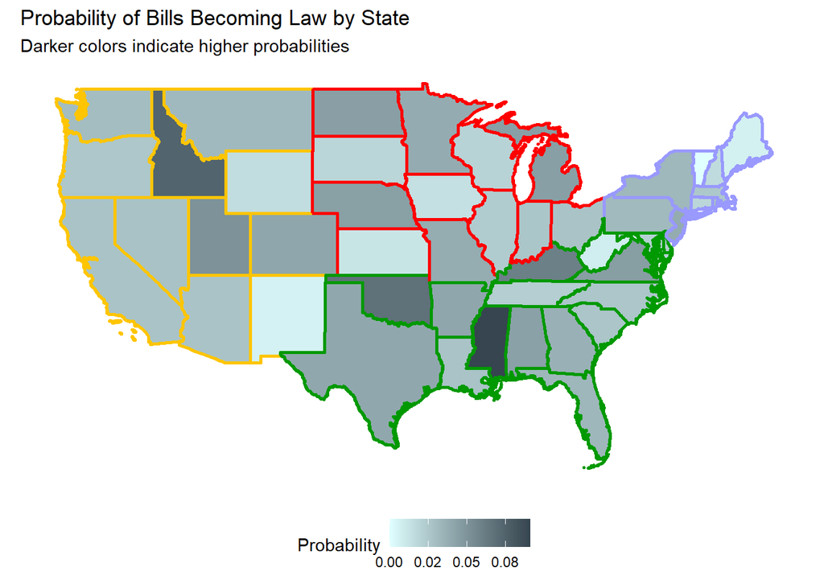

# Graphical Determinants of Cosporship

This section briefly describes how did cosponsorship vary over time.

From Figure 2 - Variation of Cosponsorship by Congress - we can observe that the values described above are derived by the frequent outliers observed in each of the congresses analyzed.

Because the 5 boxplots, containing data from 25th to 75th percentile, are generally close to 0, in the following graphs we show how mean and median varies, both when excluding and including the bills with 0 cosponsors. Overall, as explained, in this setting, the median appears more informative than the average. Then, the effective number of co-sponsors is around 4.

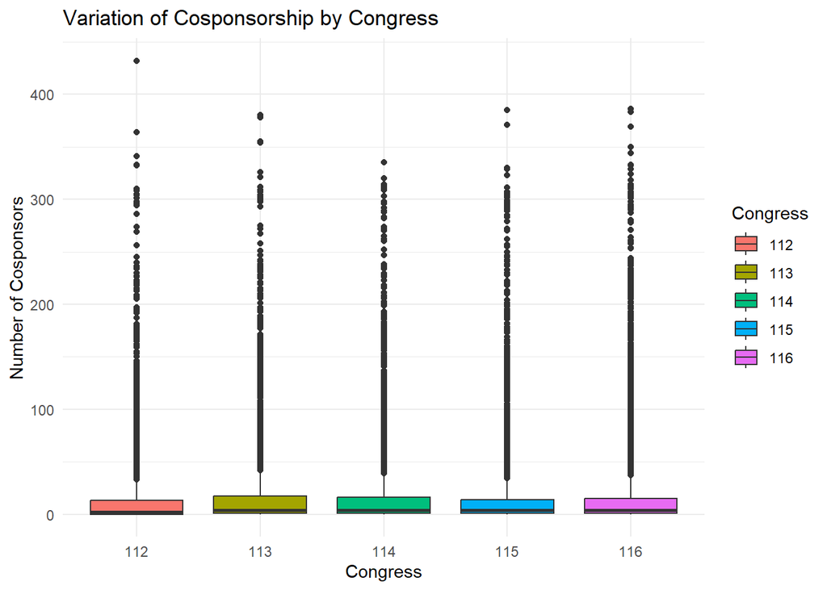

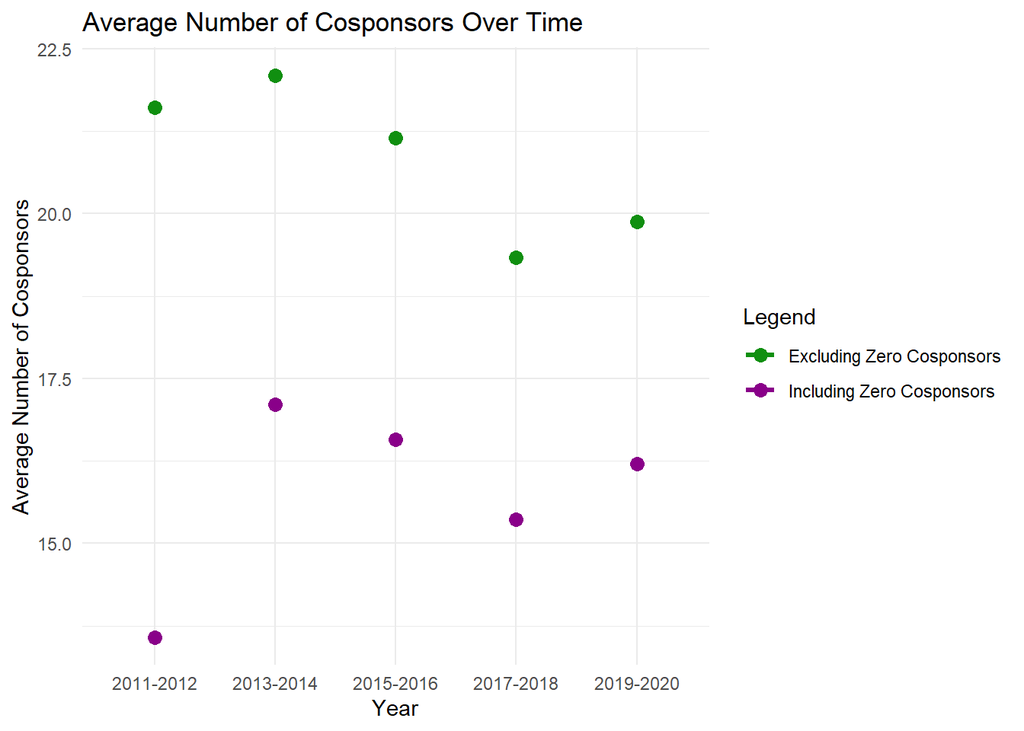

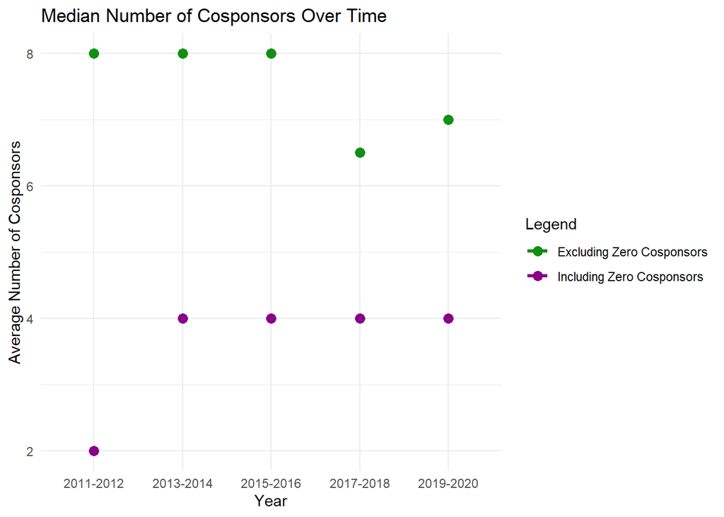

# Determinants of Cosponsorship

```
##
## Regression Results
## ====================================================================
##                                         Dependent variable:
##                                 ------------------------------------
##                                            N. Cosponsors
##                                   (1)     (2)       (3)       (4)
## --------------------------------------------------------------------
## Sponsor's Party                 1.242** -1.345**   0.183   -2.368***
##                                 (0.431) (0.496)   (0.391)   (0.459)
##
## Majority                                4.652***           4.683***
##                                         (0.444)             (0.443)
##
## Constant                         2.660   1.624   13.112*** 11.986***
##                                 (2.119) (2.118)   (0.603)   (0.611)
##
## --------------------------------------------------------------------
## Fixed Effects: Sponsor's State    Yes     Yes       No        No
## Fixed Effects: Sponsor's Region   No       No       Yes       Yes
## Fixed Effects: Congress Year      Yes     Yes       Yes       Yes
## Observations                    35,521   35,521   35,521    35,521
## Adjusted R2                      0.008   0.011     0.003     0.006
## ====================================================================
## Note:                                  *p<0.05; **p<0.01; ***p<0.001
```

```
##
## Regression Results (LPM)
## ======================================================================
##                                          Dependent variable:
##                                ---------------------------------------
##                                Prob(Passed House)       Prob(Law)
##                                   (1)       (2)       (3)       (4)
## ----------------------------------------------------------------------
## Num Cosponsor                  0.001***  0.0004*** 0.0003*** -0.0001**
##                                (0.00005) (0.0001)  (0.00003) (0.00003)
##
## Same Party-State                         0.008***            0.009***
##                                           (0.001)            (0.0003)
##
## Sponsor's Party                0.051***  0.052***  0.014***  0.015***
##                                 (0.004)   (0.004)   (0.003)   (0.002)
##
## Majority                       0.059***  0.059***  0.012***  0.011***
##                                 (0.004)   (0.004)   (0.002)   (0.002)
##
## Constant                       -0.052**  -0.050**    0.011     0.013
##                                 (0.018)   (0.018)   (0.011)   (0.011)
##
## ----------------------------------------------------------------------
## Fixed Effects: Sponsor's State    Yes       Yes       Yes       Yes
## Fixed Effects: Congress Year      Yes       Yes       Yes       Yes
## Observations                    35,521    35,521    35,521    35,521
## Adjusted R2                      0.041     0.046     0.011     0.031
## ======================================================================
## Note:                                    *p<0.05; **p<0.01; ***p<0.001
```

```
##
## Regression Results (Probit)
## ========================================================================
##                                           Dependent variable:
##                                -----------------------------------------
##                                 Prob(Passed House)        Prob(Law)
##                                   (1)        (2)        (3)       (4)
## ------------------------------------------------------------------------
## Num Cosponsor                   0.003***   0.002***  0.003***   -0.0001
##                                 (0.0002)   (0.0003)  (0.0003)  (0.0004)
##
## Same Party-State                           0.036***            0.063***
##                                            (0.003)              (0.003)
##
## Sponsor's Party                 0.296***   0.314***  0.182***  0.230***
##                                 (0.027)    (0.027)    (0.039)   (0.041)
##
## Majority                        0.365***   0.369***  0.169***  0.176***
##                                 (0.024)    (0.024)    (0.035)   (0.037)
##
## Constant                       -2.243***  -2.254***  -2.163*** -2.187***
##                                 (0.114)    (0.114)    (0.144)   (0.145)
##
## ------------------------------------------------------------------------
## Fixed Effects: Sponsor's State    Yes        Yes        Yes       Yes
## Fixed Effects: Congress Year      Yes        Yes        Yes       Yes
## Observations                     35,521     35,521    35,521    35,521
## Akaike Inf. Crit.              21,898.080 21,716.200 9,669.242 9,274.975
## ========================================================================
## Note:                                      *p<0.05; **p<0.01; ***p<0.001
```